# Clusterin project

Jakub Laszczyk, Kevin Lember, Artur Leppik

26 de enero de 2024

# 1 Data and goal

The file Vinos (Wines) contains the results of a chemical analysis conducted on 178 Vinos from a region in Italy originating from three different cultivation areas.

The variables in the file include the cultivation area (cultivo) from which the wine comes (1, 2, or 3) and the quantities of: alcohol (in %), malic acid, ash (cenizas), ash alkalinity, magnesium, total phenols, flavonoid phenols, non-flavonoid phenols, and proanthocyanidins (in g/l), color intensity, hue (tonalidad), OD280/OD315 of the diluted wine (without units of measurement), and proline (in ppm).

The goal is to group Vinos with similar compositions and determine if Vinos from the same area are grouped together.

Source: https://archive.ics.uci.edu/ml/datasets/Wine.

# 2 Data preparation

```r
load("Vinos.RData")
library(fpc)
library(ggplot2)
library(GGally)
library(factoextra)
require(RcmdrMisc)
data <- Vinos[,-1]
names(data)
```

```
##  [1] "Alcohol"
##  [2] "Ácido.Málico"
##  [3] "Cenizas"
##  [4] "Alcalinidad.Cenizas"
##  [5] "Magnesio"
##  [6] "Fenoles"
##  [7] "Flavonoides"
##  [8] "Fenoles.no.flavonoides"
##  [9] "Proantocianidinas"
## [10] "Intensidad.color"
## [11] "Tonalidad"
## [12] "Ratio.absOD280.absOD315.vino.diluido"
## [13] "Prolina"
```

# 3 Correlation Matrix

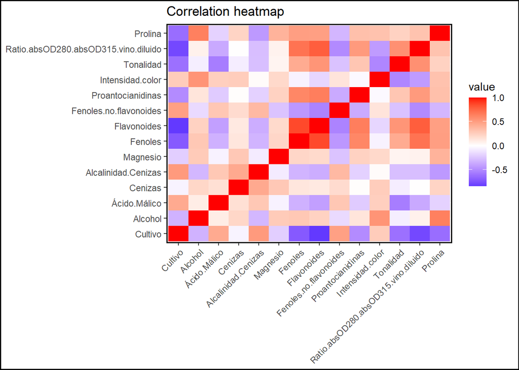

```r
cor_matrix <- cor(Vinos)

cor_df <- reshape2::melt(cor_matrix)

# Visualisation
ggplot(cor_df, aes(Var1, Var2, fill = value)) +
  geom_tile() +
  scale_fill_gradient2(low = "blue", high = "red", mid = "white", midpoint = 0) +
  labs(title = "Correlation heatmap") +
  theme(panel.border = element_rect(color = 'black',fill = NA,size = 1),
      panel.background = element_rect(fill='gray95'),
      plot.background = element_rect(color = 'black', size = 1),
      axis.text.x = element_text(angle = 45, hjust = 1),
      axis.title.x = element_blank(),
      axis.title.y = element_blank())
```

The darker red squares indicate stronger positive correlations between the variables. The darker blue squares indicate stronger negative correlations. The lighter shades, both red and blue, represent weaker correlations. Squares that are white or very light in color represent little to no correlation.

For conclusion:

Positive correlation among phenolic compounds: The strong positive correlation between “Fenoles,” “Flavonoides,” and “Proantocianidinas” suggests that vines with higher total phenolic content also tend to have higher levels of specific phenolic compounds like flavonoids and proanthocyanidins.

**Preprocessing**

Calculate measures of central tendency and dispersion, and decide whether it is advisable to scale the data. Check for missing data.

Use box plots to examine if there are outliers.

Based on the above measures and plots, decide which variables best distinguish the cultivation areas.

```r
#checking for missing values
sum(is.na(Vinos))
```

```
## [1] 0
```

there are no missing values in our data set

```r
#basics statistics
summary(Vinos)
```

```
##     Cultivo         Alcohol       Ácido.Málico      Cenizas
##  Min.   :1.000   Min.   :11.03   Min.   :0.740   Min.   :1.360
##  1st Qu.:1.000   1st Qu.:12.36   1st Qu.:1.603   1st Qu.:2.210
##  Median :2.000   Median :13.05   Median :1.865   Median :2.360
##  Mean   :1.938   Mean   :13.00   Mean   :2.336   Mean   :2.367
##  3rd Qu.:3.000   3rd Qu.:13.68   3rd Qu.:3.083   3rd Qu.:2.558
##  Max.   :3.000   Max.   :14.83   Max.   :5.800   Max.   :3.230
##  Alcalinidad.Cenizas    Magnesio         Fenoles       Flavonoides
##  Min.   :10.60       Min.   : 70.00   Min.   :0.980   Min.   :0.340
##  1st Qu.:17.20       1st Qu.: 88.00   1st Qu.:1.742   1st Qu.:1.205
##  Median :19.50       Median : 98.00   Median :2.355   Median :2.135
##  Mean   :19.49       Mean   : 99.74   Mean   :2.295   Mean   :2.029
##  3rd Qu.:21.50       3rd Qu.:107.00   3rd Qu.:2.800   3rd Qu.:2.875
##  Max.   :30.00       Max.   :162.00   Max.   :3.880   Max.   :5.080
##  Fenoles.no.flavonoides Proantocianidinas Intensidad.color   Tonalidad
##  Min.   :0.1300         Min.   :0.410     Min.   : 1.280   Min.   :0.4800
##  1st Qu.:0.2700         1st Qu.:1.250     1st Qu.: 3.220   1st Qu.:0.7825
##  Median :0.3400         Median :1.555     Median : 4.690   Median :0.9650
##  Mean   :0.3619         Mean   :1.591     Mean   : 5.058   Mean   :0.9574
##  3rd Qu.:0.4375         3rd Qu.:1.950     3rd Qu.: 6.200   3rd Qu.:1.1200
##  Max.   :0.6600         Max.   :3.580     Max.   :13.000   Max.   :1.7100
##  Ratio.absOD280.absOD315.vino.diluido    Prolina
##  Min.   :1.270                        Min.   : 278.0
##  1st Qu.:1.938                        1st Qu.: 500.5
##  Median :2.780                        Median : 673.5
##  Mean   :2.612                        Mean   : 746.9
##  3rd Qu.:3.170                        3rd Qu.: 985.0
##  Max.   :4.000                        Max.   :1680.0
```

From summary we can conclude that it’s necessary to scale the data, because variables have values in different ranges.

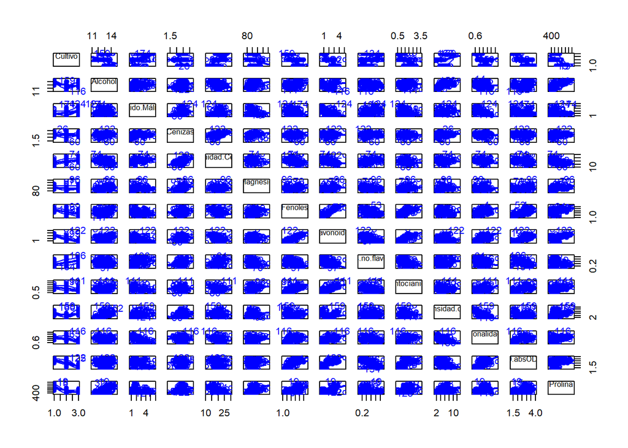

```r
#scatterplot
scatterplotMatrix(Vinos, id=list(method="mahal", n=2), diagonal=list(method="none"))
```

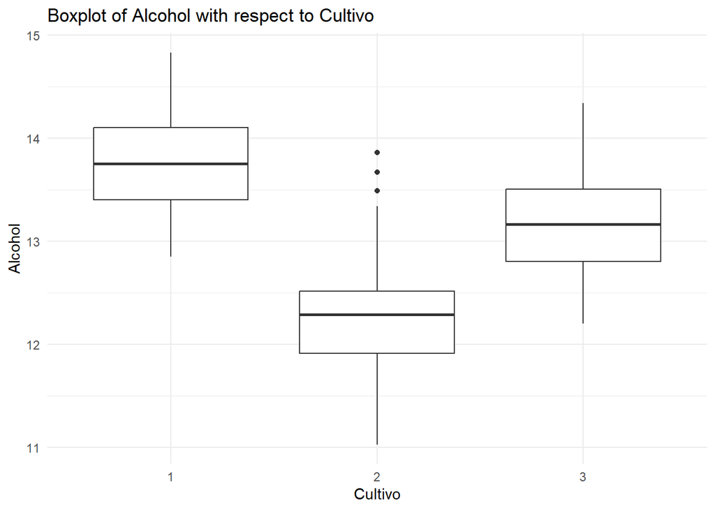

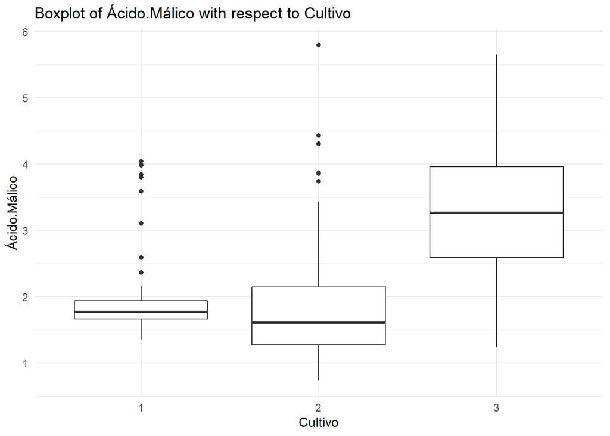

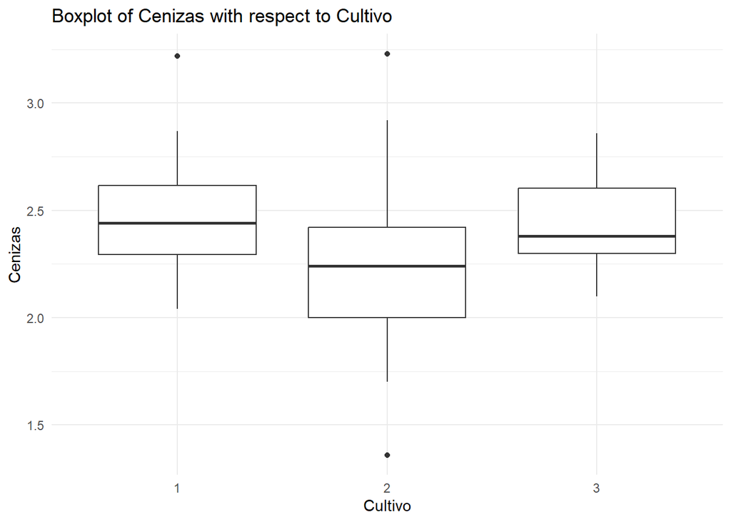

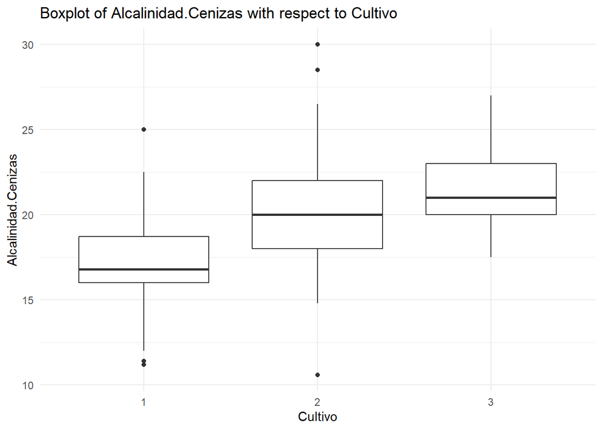

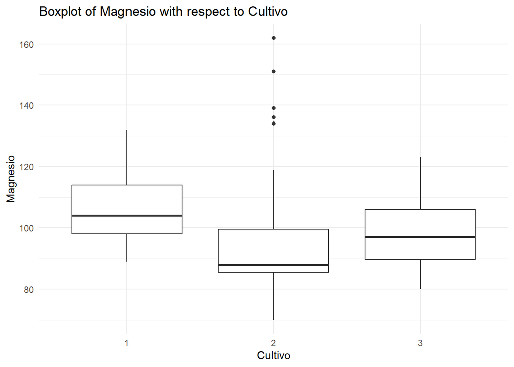

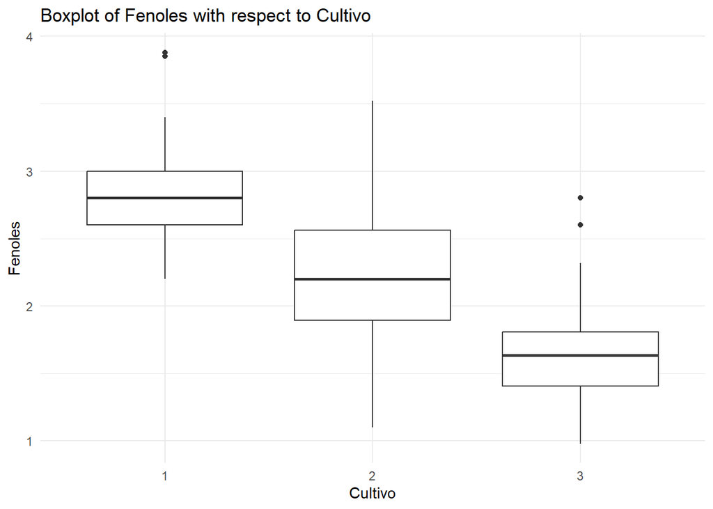

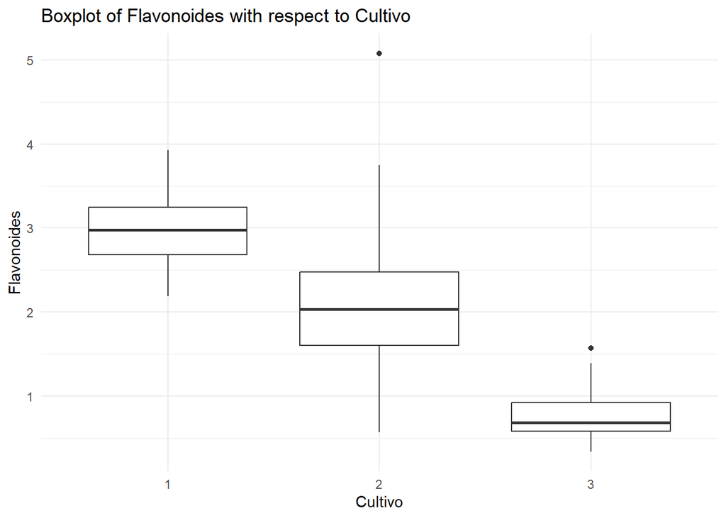

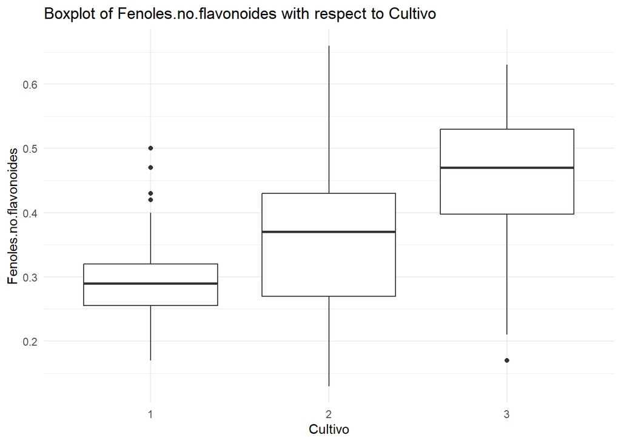

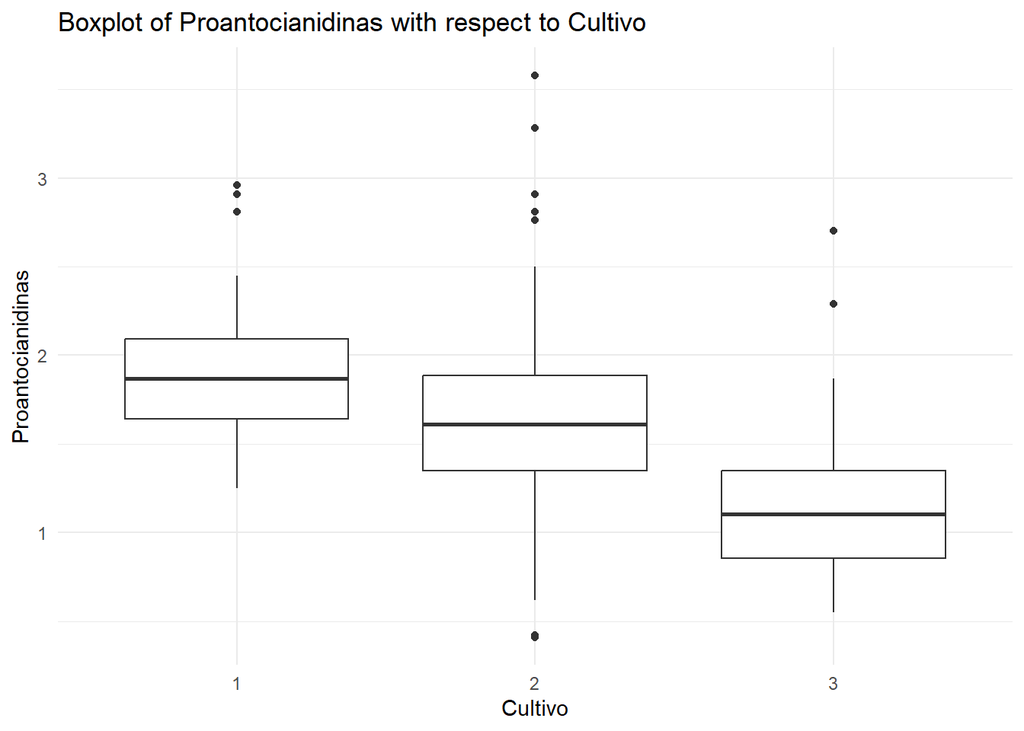

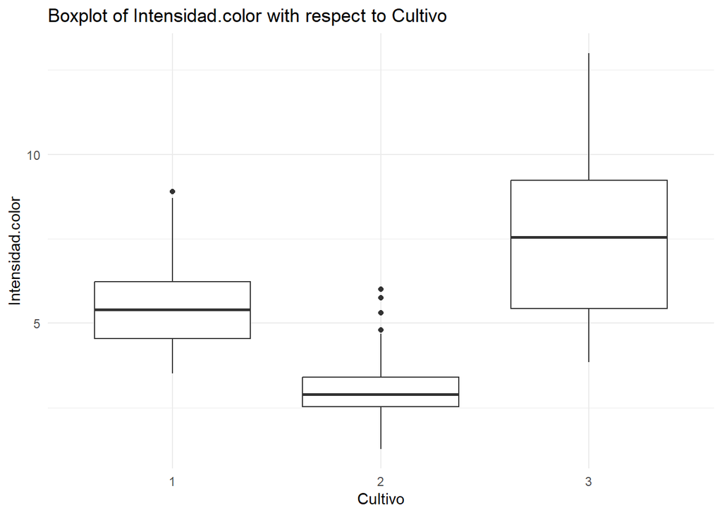

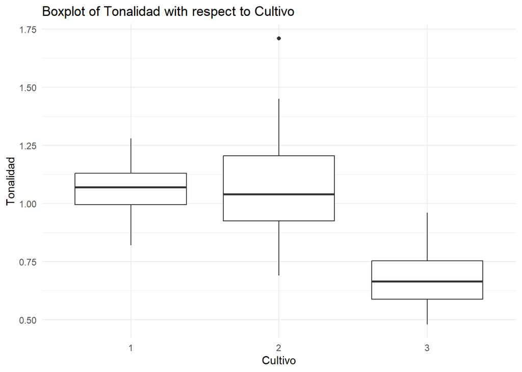

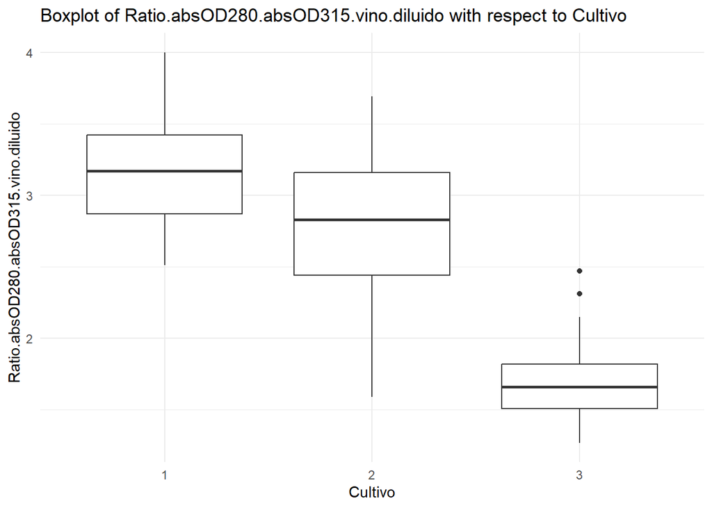

[1 more figures not shown]

```r
Vinos$Cultivo <- as.factor(Vinos$Cultivo)

# Function to create boxplots for each column with respect to 'Cultivo'
create_boxplots <- function(data, response) {
  plots <- lapply(names(data)[-1], function(col) {
    ggplot(data, aes_string(x = "Cultivo", y = col)) +
      geom_boxplot() +
      labs(x = "Cultivo", y = col, title = paste("Boxplot of", col, "with respect to Cultivo")) +
      theme_minimal()
  })
  return(plots)
}

boxplots_list <- create_boxplots(Vinos, response = "Cultivo")
boxplots_list
```

We can see in boxplots that there are some outliers but there is not enough of them to impact the results so there is no need to remove them. We can also notice that some of the variables (for example: Prolina,Ratio.absOD280.absOD315.vino.diluido,Flavonoides,Alcohol) are more related to the region they are coming from.

# 4 Dimensionality reduction

Calculate the principal components, interpret the first two, and indicate the percentage of variance they explain.

```r
CA.pc<-princomp(~. ,data= data, cor=TRUE, scores=TRUE)
  cat("\nComponent loadings:\n")
```

```
##
## Component loadings:
```

```r
  print(unclass(loadings(CA.pc)))
```

```
##                                            Comp.1       Comp.2      Comp.3
## Alcohol                               0.144329395  0.483651548  0.20738262
## Ácido.Málico                         -0.245187580  0.224930935 -0.08901289
## Cenizas                              -0.002051061  0.316068814 -0.62622390
## Alcalinidad.Cenizas                  -0.239320405 -0.010590502 -0.61208035
## Magnesio                              0.141992042  0.299634003 -0.13075693
## Fenoles                               0.394660845  0.065039512 -0.14617896
## Flavonoides                           0.422934297 -0.003359812 -0.15068190
## Fenoles.no.flavonoides               -0.298533103  0.028779488 -0.17036816
## Proantocianidinas                     0.313429488  0.039301722 -0.14945431
## Intensidad.color                     -0.088616705  0.529995672  0.13730621
## Tonalidad                             0.296714564 -0.279235148 -0.08522192
## Ratio.absOD280.absOD315.vino.diluido  0.376167411 -0.164496193 -0.16600459
## Prolina                               0.286752227  0.364902832  0.12674592
##                                           Comp.4      Comp.5      Comp.6
## Alcohol                               0.01785630  0.26566365  0.21353865
## Ácido.Málico                         -0.53689028 -0.03521363  0.53681385
## Cenizas                               0.21417556  0.14302547  0.15447466
## Alcalinidad.Cenizas                  -0.06085941 -0.06610294 -0.10082451
## Magnesio                              0.35179658 -0.72704851  0.03814394
## Fenoles                              -0.19806835  0.14931841 -0.08412230
## Flavonoides                          -0.15229479  0.10902584 -0.01892002
## Fenoles.no.flavonoides                0.20330102  0.50070298 -0.25859401
## Proantocianidinas                    -0.39905653 -0.13685982 -0.53379539
## Intensidad.color                     -0.06592568  0.07643678 -0.41864414
## Tonalidad                             0.42777141  0.17361452  0.10598274
## Ratio.absOD280.absOD315.vino.diluido -0.18412074  0.10116099  0.26585107
## Prolina                               0.23207086  0.15786880  0.11972557
##                                           Comp.7      Comp.8      Comp.9
## Alcohol                               0.05639636  0.39613926  0.50861912
## Ácido.Málico                         -0.42052391  0.06582674 -0.07528304
## Cenizas                               0.14917061 -0.17026002 -0.30769445
## Alcalinidad.Cenizas                   0.28696914  0.42797018  0.20044931
## Magnesio                             -0.32288330 -0.15636143  0.27140257
## Fenoles                               0.02792498 -0.40593409  0.28603452
## Flavonoides                           0.06068521 -0.18724536  0.04957849
## Fenoles.no.flavonoides               -0.59544729 -0.23328465  0.19550132
## Proantocianidinas                    -0.37213935  0.36822675 -0.20914487
## Intensidad.color                      0.22771214 -0.03379692  0.05621752
## Tonalidad                            -0.23207564  0.43662362  0.08582839
```

[output cut: 15 more lines]

```
## Prolina                               0.16211600 -0.53926983  0.07940162
##                                          Comp.13
## Alcohol                               0.01496997
## Ácido.Málico                          0.02596375
## Cenizas                              -0.14121803
## Alcalinidad.Cenizas                   0.09168285
## Magnesio                              0.05677422
## Fenoles                              -0.46390791
## Flavonoides                           0.83225706
## Fenoles.no.flavonoides                0.11403985
## Proantocianidinas                    -0.11691707
## Intensidad.color                     -0.01199280
## Tonalidad                            -0.08988884
## Ratio.absOD280.absOD315.vino.diluido -0.15671813
## Prolina                               0.01444734
```

```r
cat("\nComponent variances:\n")
```

```
##
## Component variances:
```

```r
  print(CA.pc$sd^2)
```

```
##    Comp.1    Comp.2    Comp.3    Comp.4    Comp.5    Comp.6    Comp.7    Comp.8
## 4.7058503 2.4969737 1.4460720 0.9189739 0.8532282 0.6416570 0.5510283 0.3484974
##    Comp.9   Comp.10   Comp.11   Comp.12   Comp.13
## 0.2888799 0.2509025 0.2257886 0.1687702 0.1033779
```

```r
  cat("\n")
```

```r
  print(summary(CA.pc))
```

```
## Importance of components:
##                           Comp.1    Comp.2    Comp.3    Comp.4     Comp.5
## Standard deviation     2.1692972 1.5801816 1.2025273 0.9586313 0.92370351
## Proportion of Variance 0.3619885 0.1920749 0.1112363 0.0706903 0.06563294
## Cumulative Proportion  0.3619885 0.5540634 0.6652997 0.7359900 0.80162293
##                            Comp.6     Comp.7     Comp.8     Comp.9    Comp.10
## Standard deviation     0.80103498 0.74231281 0.59033665 0.53747553 0.50090167
## Proportion of Variance 0.04935823 0.04238679 0.02680749 0.02222153 0.01930019
## Cumulative Proportion  0.85098116 0.89336795 0.92017544 0.94239698 0.96169717
##                           Comp.11    Comp.12     Comp.13
## Standard deviation     0.47517222 0.41081655 0.321524394
## Proportion of Variance 0.01736836 0.01298233 0.007952149
## Cumulative Proportion  0.97906553 0.99204785 1.000000000
```

**Comp.1**: It has a variance of approximately 4.71, which is the highest among all the components.

**Comp.2**: The second component has a variance of approximately 2.50, which is lower than Component 1 but still significant.

In summary, Comp.1 is the most influential in terms of explaining the variability in your dataset, indicating that it captures the essence of the data to a great extent. Comp.2 is also important but to a lesser degree than Comp.1. Together, these two components explain over half of the variability in the data, which can be quite significant depending on the complexity and size of the dataset.

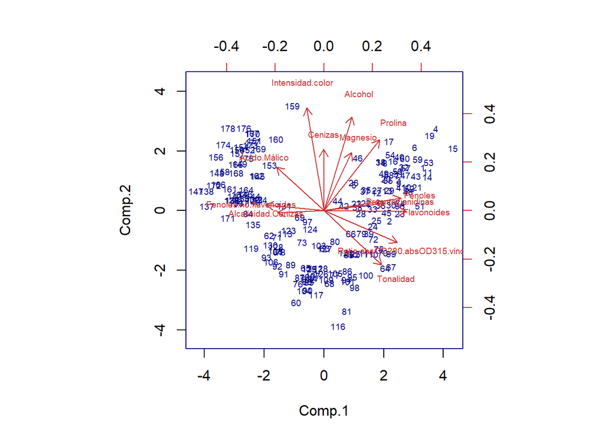

```r
biplot(CA.pc, scale = 0, cex = 0.6, col = c("blue4", "brown3"))
```

**“Flavonoides” and “Fenoles”:**

Since both “Flavonoides” and “Fenoles” vectors are pointing in a similar direction, this suggests that wines with a higher content of phenols also have higher amounts of flavonoids.

**“Ácido.Málico” and “Alcalinidad.Cenizas”:**

If the “Ácido.Málico” vector points in a different direction from the “Alcalinidad.Cenizas” vector, it may indicate that wines with higher malic acid levels tend to have lower ash alkalinity, or vice versa.

**“Proantocianidinas” and “Color Intensity”:**

**“Fenoles.no.flavonoides” and “Flavonoides”:**

**“Ratio.abs” and “Proantocianidinas”:**

```r
CA.sc<-scale(data)
dist.CAsc<-dist(CA.sc, method = "canberra")


hc.CAsc<-hclust(dist.CAsc, method = "ward.D2")
print(hc.CAsc) #Devuelve el método con el que se ha obtenido el árbol
```

```
##
## Call:
## hclust(d = dist.CAsc, method = "ward.D2")
##
## Cluster method   : ward.D2
## Distance         : canberra
## Number of objects: 178
```

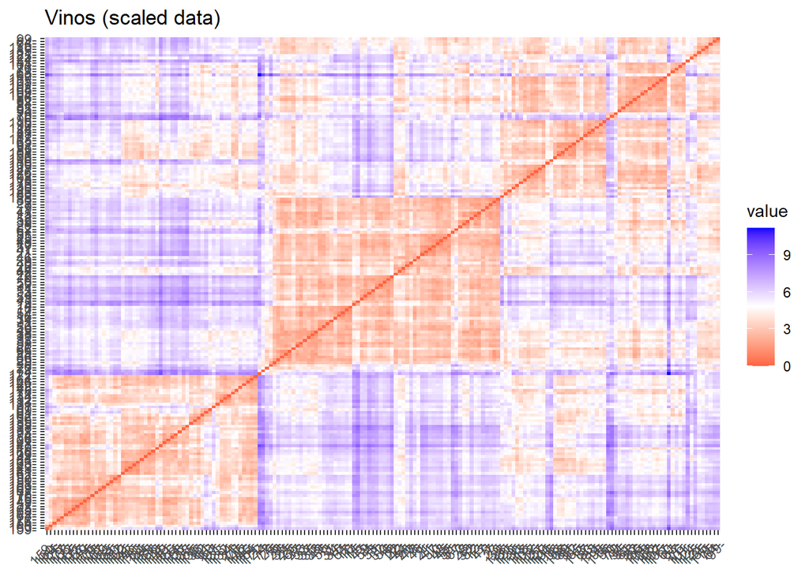

```r
dataCA.sc<-scale(data)
fviz_dist(dist(dataCA.sc), show_labels = TRUE)+
labs(title = "Vinos (scaled data)")
```

We can see that there are 3 areas that we can distinguish that are indicating three possible clusters.

2. **DENDOGRAM**

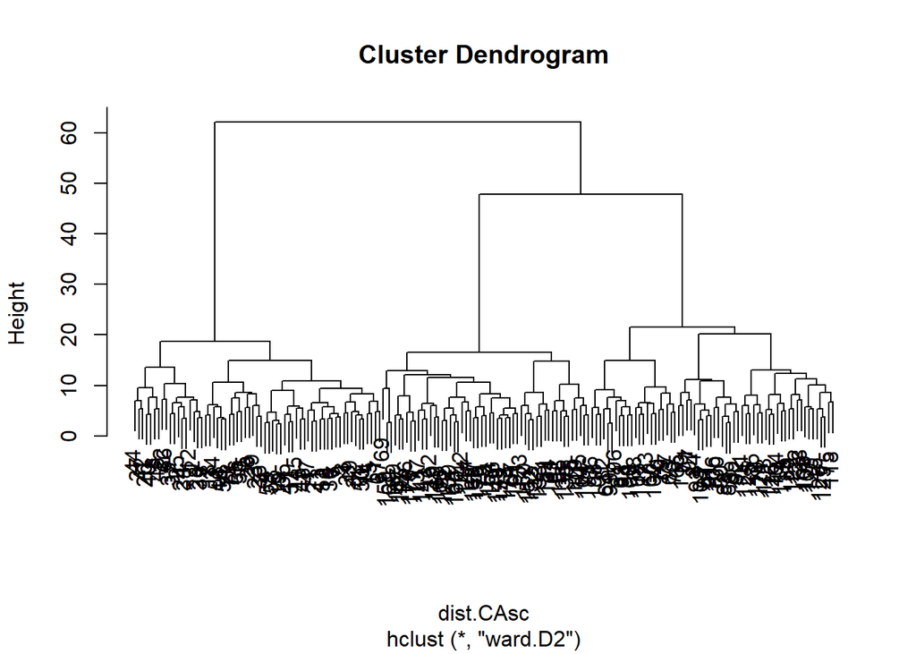

```r
plot(hc.CAsc)
```

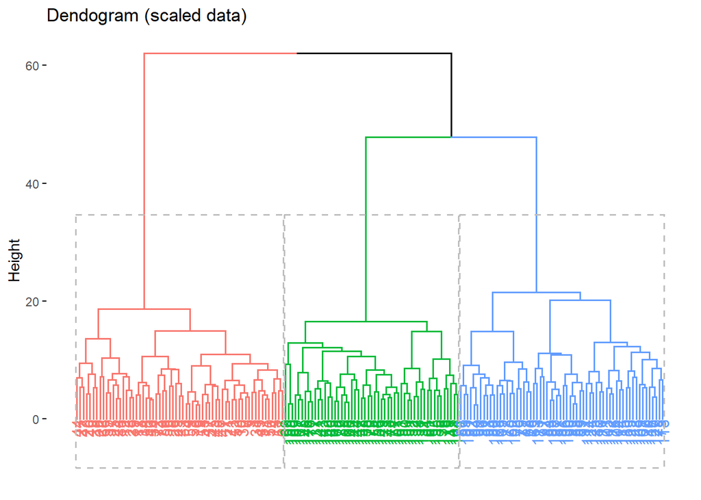

```r
fviz_dend(hc.CAsc, k=3, data = CA.sc,
  #k_colors= c("green", "#00AFBB", "#E7B800", "#FC4E07"),
  show_labels = TRUE, #defecto
  rect=TRUE, #defecto FALSE. Hay también opciones para su formato
  main = "Dendogram (scaled data)",
  sub = "Euclidean distance and complete linkage"
)
```

The height at which two items join represents the distance or dissimilarity between them. A short height indicates high similarity. The structure of the dendrogram allows us to infer the number of clusters by cutting the “tree” at different heights.

3. **elbow method**

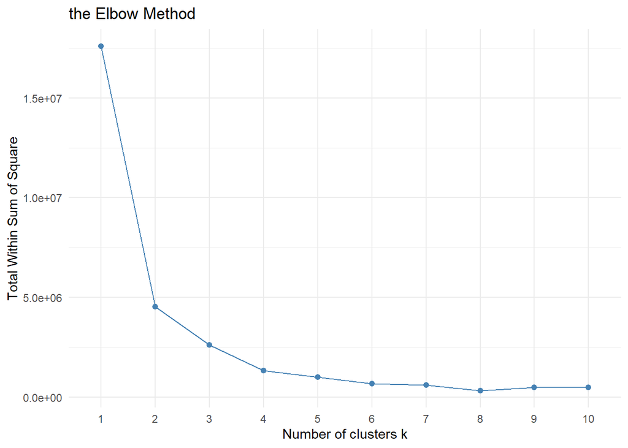

```r
set.seed(31)
# function to compute total within-cluster sum of squares
fviz_nbclust(data, kmeans, method = "wss", k.max = 10) + theme_minimal() + ggtitle("the Elbow Method")
```